# Line chart with 95% confidence interval in Stata

Mark Bounthavong

10/29/2022

## Introduction

[Stata](https://www.stata.com/company/) is a statistical software the is used to perform statistical analysis. It is one of my favorite statistical software, and I use it for many of my projects. Stata also has a powerful graphic editing tool that allows for a full range of customization. However, I like to keep all of these in the code so that I can have a convenient template to re-create my custom figures.

One figure that I generate often in Stata is the connected line plot, whch uses the `connected` command. Here is an example of what that looks like. Notice how each point is connected by a line. Each point represents the average price for each category of `rep78`. However, if I wanted to add the 95% confidence interval error bars, I will need to do more coding.

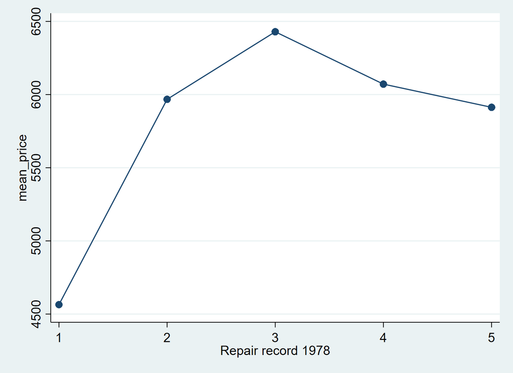

## Objective

To add 95% CI to the Stata `connected` line plot, we will use the [Medical Expenditure Panel Survey (MEPS)](https://www.meps.ahrq.gov/mepsweb/) from the Agency for Healthcare Research and Quality (AHRQ). I have already downloaded and cleaned the data from this tutorial, which is available on my [Dropbox folder](https://www.dropbox.com/sh/ophzbm5u1hc5j3x/AAAKpxAmgUtWm5fc87bzjO-la?dl=0). Make sure to download the data and save it on the folder where you are going to perform this exercise.

## Motivating example

In this tutorial, we are interested in plotting the average total healthcare expenditures along with the 95% CI of responders from 2008 to 2019.

### Step 1: Load the data into Stata

First, we will need to load the data into Stata. The data we will use for this tutorial is `adjusted_combined_data_post.dta`.

```stata
// Use the data from the following Dropbox folder:
* For Windows:
clear all
cd "C:\Users\mbounthavong\Dropbox\Marks blog\Stata in R Markdown"
use adjusted_combined_data_post.dta
```

```
C:\Users\mbounthavong\Dropbox\Marks blog\Stata in R Markdown
```

### Step 2: Visualize the data

Let’s look at the number of subjects we have across the years. There are twelve years of data from 2008 - 2019.

```
. tab year, m

       year |      Freq.     Percent        Cum.
------------+-----------------------------------
       2008 |     23,183        7.84        7.84
       2009 |     26,008        8.79       16.63
       2010 |     23,434        7.92       24.56
       2011 |     25,226        8.53       33.09
       2012 |     27,820        9.41       42.50
       2013 |     26,316        8.90       51.39
       2014 |     24,899        8.42       59.81
       2015 |     25,577        8.65       68.46
       2016 |     25,200        8.52       76.98
       2017 |     23,529        7.96       84.94
       2018 |     22,811        7.71       92.65
       2019 |     21,722        7.35      100.00
------------+-----------------------------------
      Total |    295,725      100.00
```

### Step 3: Two-way line plot

We can create a two-way line plot using the `connected` command. We’ll plot he average total healthcare expenditure again the years (2008-2019).

We estimate the mean total healthcare expenditure using the `egen` command by year. Then we use the `graph twoway connected` code to generate the two-way line plot. Before you plot the figure, make sure that you sort by year. Otherwise, you will be a spaghetti-like plot where Stata will try to draw the line across the years if they are not sorted or in order.

```
. egen mean_expenditure = mean(totexp), by(year)

. sort year

. graph twoway connected mean_expenditure year, ///
>       title("Total healthcare expenditures (2008-2019)") ///
>       ytitle("Average total healthcare expenditure ($)") ///
>       xtitle("Time (year)") ///
>       xlab(2008(1)2019) ///
>       ylab(, labsize(small) nogrid) ///
>       graphregion(color(white)) ///
>       bgcolor(white)

. graph export "connected1.png", replace
file connected1.png saved as PNG format
```

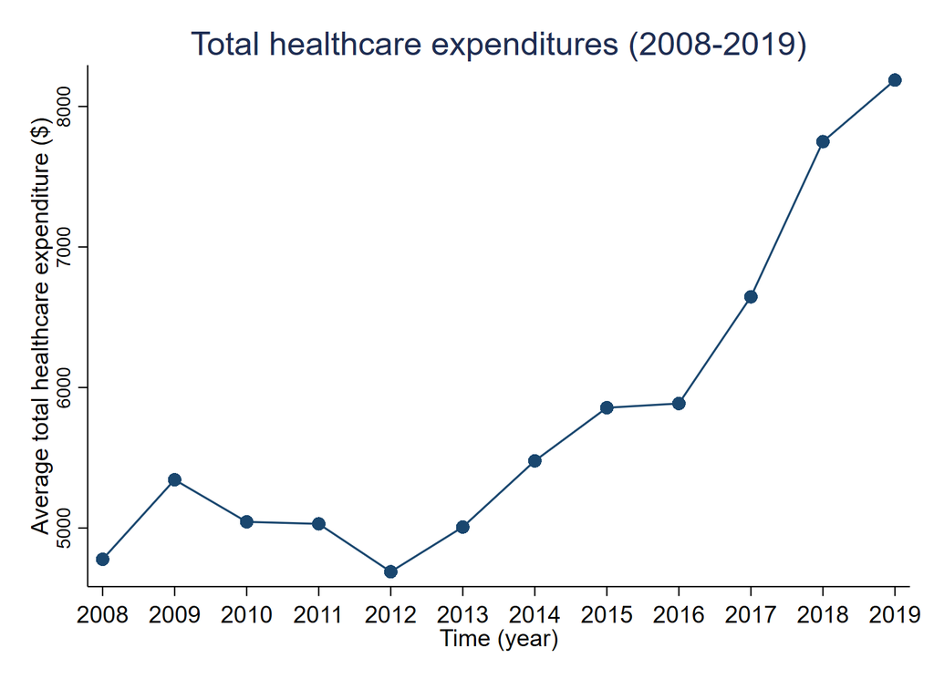

### Step 4: Estimate the 95% CI

So far, our plot only illustrates the average total healthcare expenditure across time. But we want to plot the average total healthcare expenditures with 95% confidence intervals (CI). The 95% CI is important because it will give us some visual indicator of the variance surrounding each value.

We will need to estimate the 95% CI for each value. We can get the 95% CI for each value by using the `ci means` command.

```
. egen mean_expenditure = mean(totexp), by(year)

. ci means mean_expenditure

    Variable |        Obs        Mean    Std. err.       [95% conf. interval]
-------------+---------------------------------------------------------------
mean_expen~e |    295,725    5757.172    1.967669        5753.315    5761.028
```

This gives us the 95% CI for the pooled total healthcare expenditure. If we want to get the 95% CI for each year, we need to specify the year. We use the `forvalues` loop to cycle through the years and estimate the mean, standard error, and 95% CI for the total healthcare expenditure at each year (2008-2019).

```
. forvalues i = 2008/2019 {
  2.         ci mean totexp if year == `i'
  3.   }

    Variable |        Obs        Mean    Std. err.       [95% conf. interval]
-------------+---------------------------------------------------------------
      totexp |     23,183    4777.358    80.79093        4619.002    4935.713

    Variable |        Obs        Mean    Std. err.       [95% conf. interval]
-------------+---------------------------------------------------------------
      totexp |     26,008    5343.664    89.85267        5167.548     5519.78

    Variable |        Obs        Mean    Std. err.       [95% conf. interval]
-------------+---------------------------------------------------------------
      totexp |     23,434     5043.94    91.67762        4864.246    5223.634

    Variable |        Obs        Mean    Std. err.       [95% conf. interval]
-------------+---------------------------------------------------------------
      totexp |     25,226    5029.757    140.6383        4754.098    5305.416

    Variable |        Obs        Mean    Std. err.       [95% conf. interval]
-------------+---------------------------------------------------------------
      totexp |     27,820    4688.955    89.59223         4513.35     4864.56

    Variable |        Obs        Mean    Std. err.       [95% conf. interval]
-------------+---------------------------------------------------------------
      totexp |     26,316    5007.205    89.70101        4831.386    5183.024

    Variable |        Obs        Mean    Std. err.       [95% conf. interval]
-------------+---------------------------------------------------------------
      totexp |     24,899     5477.92      101.46        5279.053    5676.788

    Variable |        Obs        Mean    Std. err.       [95% conf. interval]
-------------+---------------------------------------------------------------
      totexp |     25,577    5856.111    112.1399         5636.31    6075.911

    Variable |        Obs        Mean    Std. err.       [95% conf. interval]
-------------+---------------------------------------------------------------
      totexp |     25,200     5886.41    101.2013        5688.049     6084.77

    Variable |        Obs        Mean    Std. err.       [95% conf. interval]
-------------+---------------------------------------------------------------
      totexp |     23,529    6645.628    122.1442        6406.217    6885.038

    Variable |        Obs        Mean    Std. err.       [95% conf. interval]
-------------+---------------------------------------------------------------
      totexp |     22,811    7749.712    134.2076        7486.656    8012.768

    Variable |        Obs        Mean    Std. err.       [95% conf. interval]
-------------+---------------------------------------------------------------
      totexp |     21,722    8187.724    142.8591        7907.709    8467.738
```

### Step 5: Generate the high and low values of the 95% CI

We start by adding two new variables: `high` and `low`, which are the high and low ends of the 95% CI. Then we estimate the 95% CI for the total healthcare expenditure at each year. The data are stored in Stata and can be retrieved using the `r()` syntax. For example, if I want the lower bound of the 95% CI in 2009, then I write `replace low = r(lb) if year == 2009`.

To make this process more efficient, we use the `forvalues` loop for each year (2008-2019).

```
. // Generate the upper and low bound of the 95% CI variable
. gen high = .
(295,725 missing values generated)

. gen low = .
(295,725 missing values generated)

.
. // Loop commmand
. forvalues i = 2008/2019 {
  2.         ci mean totexp if year == `i'
  3.         replace high = r(ub) if year == `i'
  4.         replace low = r(lb) if year == `i'
  5. }

    Variable |        Obs        Mean    Std. err.       [95% conf. interval]
-------------+---------------------------------------------------------------
      totexp |     23,183    4777.358    80.79093        4619.002    4935.713
(23,183 real changes made)
(23,183 real changes made)

    Variable |        Obs        Mean    Std. err.       [95% conf. interval]
-------------+---------------------------------------------------------------
      totexp |     26,008    5343.664    89.85267        5167.548     5519.78
(26,008 real changes made)
(26,008 real changes made)

    Variable |        Obs        Mean    Std. err.       [95% conf. interval]
-------------+---------------------------------------------------------------
      totexp |     23,434     5043.94    91.67762        4864.246    5223.634
(23,434 real changes made)
(23,434 real changes made)

    Variable |        Obs        Mean    Std. err.       [95% conf. interval]
-------------+---------------------------------------------------------------
      totexp |     25,226    5029.757    140.6383        4754.098    5305.416
(25,226 real changes made)
(25,226 real changes made)

    Variable |        Obs        Mean    Std. err.       [95% conf. interval]
```

[output cut: 31 more lines]

```
      totexp |     23,529    6645.628    122.1442        6406.217    6885.038
(23,529 real changes made)
(23,529 real changes made)

    Variable |        Obs        Mean    Std. err.       [95% conf. interval]
-------------+---------------------------------------------------------------
      totexp |     22,811    7749.712    134.2076        7486.656    8012.768
(22,811 real changes made)
(22,811 real changes made)

    Variable |        Obs        Mean    Std. err.       [95% conf. interval]
-------------+---------------------------------------------------------------
      totexp |     21,722    8187.724    142.8591        7907.709    8467.738
(21,722 real changes made)
(21,722 real changes made)
```

### Step 6: Plot the 95% CI

Now, that we have the 95% CI for total healthcare expenditure at each year, we can plot these using the `rcap` command. This allows us to create error bars using the variables we generated for the upper `high` and lower `low` bounds of the 95% CI.

```
(295,725 missing values generated)

(295,725 missing values generated)

    Variable |        Obs        Mean    Std. err.       [95% conf. interval]
-------------+---------------------------------------------------------------
      totexp |     23,183    4777.358    80.79093        4619.002    4935.713
(23,183 real changes made)
(23,183 real changes made)

    Variable |        Obs        Mean    Std. err.       [95% conf. interval]
-------------+---------------------------------------------------------------
      totexp |     26,008    5343.664    89.85267        5167.548     5519.78
(26,008 real changes made)
(26,008 real changes made)

    Variable |        Obs        Mean    Std. err.       [95% conf. interval]
-------------+---------------------------------------------------------------
      totexp |     23,434     5043.94    91.67762        4864.246    5223.634
(23,434 real changes made)
(23,434 real changes made)

    Variable |        Obs        Mean    Std. err.       [95% conf. interval]
-------------+---------------------------------------------------------------
      totexp |     25,226    5029.757    140.6383        4754.098    5305.416
(25,226 real changes made)
(25,226 real changes made)

    Variable |        Obs        Mean    Std. err.       [95% conf. interval]
-------------+---------------------------------------------------------------
      totexp |     27,820    4688.955    89.59223         4513.35     4864.56
(27,820 real changes made)
(27,820 real changes made)

    Variable |        Obs        Mean    Std. err.       [95% conf. interval]
-------------+---------------------------------------------------------------
      totexp |     26,316    5007.205    89.70101        4831.386    5183.024
(26,316 real changes made)
(26,316 real changes made)

```

[output cut: 24 more lines]

```
    Variable |        Obs        Mean    Std. err.       [95% conf. interval]
-------------+---------------------------------------------------------------
      totexp |     22,811    7749.712    134.2076        7486.656    8012.768
(22,811 real changes made)
(22,811 real changes made)

    Variable |        Obs        Mean    Std. err.       [95% conf. interval]
-------------+---------------------------------------------------------------
      totexp |     21,722    8187.724    142.8591        7907.709    8467.738
(21,722 real changes made)
(21,722 real changes made)



file connected_errorbars.png saved as PNG format
```

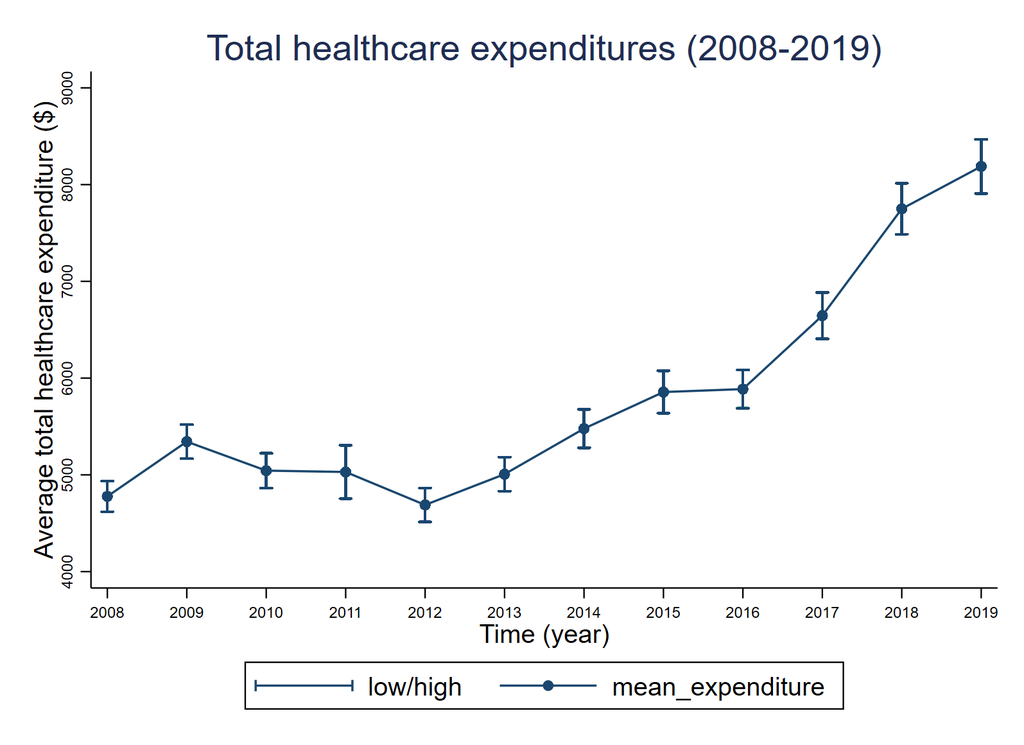

```stata
// Generate the average total healthcare expenditure by year
egen mean_expenditure = mean(totexp), by(year)


// Generate the upper and low bound of the 95% CI variable
gen high = .
gen low = .

// Loop commmand
forvalues i = 2008/2019 {
    ci mean totexp if year == `i'
    replace high = r(ub) if year == `i'
    replace low = r(lb) if year == `i'
}

// Sort by year and generate the two-way line plot
sort year
graph twoway (rcap low high year) ///
             (connected mean_expenditure year, color(navy) msize(small) ///
                        title("Total healthcare expenditures (2008-2019)") ///
                        ytitle("Average total healthcare expenditure ($)") ///
                        xtitle("Time (year)") ///
                        xlab(2008(1)2019, labsize(vsmall)) ///
                        ylab(, labsize(vsmall) nogrid) ///
                        graphregion(color(white)) ///
                        bgcolor(white) ///
                        color(navy))
graph export "connected_errorbars.png", replace
```

### Conclusions

Adding the 95% CI allows the reader to visualize the variance surrounding the mean total healthcare expenditure per year. This added dimension to the two-way line plot is useful for publication-quality images. However, these series of commands can be used for any continuous data type. I would recommend using this for data that is plotted along time on the x-axis.

### Acknowledgement

I’ve learned how to code in Stata through various resources online. Particularly, [Stats Exchange](https://stats.stackexchange.com/) and [Stata Forum](https://www.statalist.org/forums/forum/general-stata-discussion/general/1560200-adding-confidence-intervals-to-a-two-way-line-graph).

This is a work in progress, and I will likely update this as I learn more efficient methods to produce 95% CI around average values.

The Github code for this R Markdown tutorial is located [here](https://github.com/mbounthavong/STATA-programming-and-codes/blob/4201dedddd943a546f5fa8df06bc3060296f7904/two-way%20line%20plot%20and%2095%25%20confidence%20intervals).